## Pen-and-paper problems (A)

### A1

Show that:
$$\sum_{i=1}^n (x_i - \bar{x}) = 0$$
where $\bar{x}$ is a sample mean (arithmetic average). Show that the same holds for $\mathbb{E}[X$ and $\mathbb{E}[X]]$, that is:
$$\mathbb{E}[X - \mathbb{E}[X]] = 0$$
SOLUTION

To show that $\sum_{i=1}^n (x_i - \bar{x}) = 0$ is true, I will conduct a proof by contradiction. First, we assume that $\sum_{i=1}^n (x_i - \bar{x}) \neq 0$ is true and transform left side of the equation.
$$\\\sum_{i=1}^n (x_i - \bar{x}) \neq 0
\\\sum_{i=1}^n (x_i - \bar{x}) \neq 0
\\(x_1 - \bar{x}) + (x_2 - \bar{x}) + ... + (x_n - \bar{x}) \neq 0
\\x_1 + x_2 + ... + x_n - \bar{x} - \bar{x} - ... - \bar{x} \neq 0
\\x_1 + x_2 + ... + x_n - n*\bar{x} \neq 0
\\\sum_{i=1}^n x_i \neq n*\bar{x} \quad \text{ / : n, (because n > 0)}
\\ \frac {\sum_{i=1}^n x_i} {n} \neq \bar{x} \quad \text {(from definition of the mean)}
\\ \bar{x} \neq \bar{x}
\\\text{contradiction}$$

Assuming that $\sum_{i=1}^n (x_i - \bar{x}) \neq 0$ leads to a contradiction, then this assumption is false. Therefore, it is true that $\sum_{i=1}^n (x_i - \bar{x}) = 0$

Next, I will show that $\mathbb{E}[X - \mathbb{E}[X]] = 0$ is true. I will also conduct a proof by contradiction. First, let’s assume that $\mathbb{E}[X - \mathbb{E}[X]] = 0$ is false. Then, $\mathbb{E}[X - \mathbb{E}[X]] \neq 0$ is true. Left side of the equation can be transformed in this way:
$$\\\mathbb{E}[X - \mathbb{E}[X]] \neq 0
\\\mathbb{E}[X] - \mathbb{E}[\mathbb{E}[X]] \neq 0 \quad \text {from basic properties of } \mathbb{E}[X]: \mathbb{E}[\mathbb{E}[X]] = \mathbb{E}[X]
\\\mathbb{E}[X] - \mathbb{E}[X] \neq 0
\\ 0 \neq 0
\\\text {contradiction}$$
The assumption leads to a contradiction, so it is false. Therefore, it is true that $\mathbb{E}[X - \mathbb{E}[X]] = 0$

### A2

Show that:
$$\text{Var}[aX + bY] = a^2\text{Var}[X] + b^2\text{Var}[Y] + 2ab\text{Cov}[X, Y]$$
where $a$ and $b$ are two constants.

**Hint.** Start with the definition of variance:
$$\text{Var}[X] = \mathbb{E}[(X - \mathbb{E}[X])^2] = \mathbb{E}[X^2] - \mathbb{E}[X]^2$$

**Hint II.** Remember about the definition of covariance that:
$$\text{Cov}[X, Y] = \mathbb{E}[(X - \mathbb{E}[X])(Y - \mathbb{E}[Y])] = \mathbb{E}[XY] - \mathbb{E}[X]\mathbb{E}[Y]$$

SOLUTION

To show that the equation is true, I will transform the left side to obtain the right side. Each line(step) results from the previous one.
$$\\\text{Var}[aX + bY] \quad \text{from above's defition of variance}
\\\color{red}{\mathbb{E}[(aX + bY)^2]} - \color{green}{\mathbb{E}[aX + bY]^2}
\\\color{red}{\mathbb{E}[a^2X^2 + 2abXY + b^2Y^2]} - \color{green}{\mathbb{E}[aX + bY]*\mathbb{E}[aX + bY]}
\\\color{red}{\mathbb{E}[a^2X^2] + \mathbb{E}[2abXY] + \mathbb{E}[b^2Y^2]} -\color{green}{ [(\mathbb{E}[aX]+\mathbb{E}[bY])*(\mathbb{E}[aX]+\mathbb{E}[bY])]}
\\\color{red}{a^2\mathbb{E}[X^2] + 2ab\mathbb{E}[XY] + b^2\mathbb{E}[Y^2]} - \color{green}{(\mathbb{E}[aX]^2+2\mathbb{E}[aX]\mathbb{E}[bY] + \mathbb{E}[bY]^2)}
\\\color{red}{a^2\mathbb{E}[X^2] + 2ab\mathbb{E}[XY] + b^2\mathbb{E}[Y^2]} - \color{green}{\mathbb{E}[aX]^2 - 2ab\mathbb{E}[X]\mathbb{E}[Y] - \mathbb{E}[bY]^2}
\\\color{red}{2ab\mathbb{E}[XY]}- \color{green}{2ab\mathbb{E}[X]\mathbb{E}[Y]} + \color{red}{a^2\mathbb{E}[X^2] + b^2\mathbb{E}[Y^2]} - \color{green}{\mathbb{E}[aX]^2 - \mathbb{E}[bY]^2}
\\\color{magenta}{2ab(\mathbb{E}[XY]- \mathbb{E}[X]\mathbb{E}[Y])} + \color{orange}{a^2\mathbb{E}[X^2] + b^2\mathbb{E}[Y^2] - \mathbb{E}[aX]*\mathbb{E}[aX] - \mathbb{E}[bY]*\mathbb{E}[bY]}
\\\text{from defition of covariance}
\\\color{magenta}{2ab\text{Cov}[X, Y]} + \color{orange}{a^2\mathbb{E}[X^2] + b^2\mathbb{E}[Y^2] - a^2\mathbb{E}[X]^2 - b^2\mathbb{E}[Y]^2}
\\\color{magenta}{2ab\text{Cov}[X, Y]} + \color{orange}{a^2(\mathbb{E}[X^2] - \mathbb{E}[X]^2)+ b^2(\mathbb{E}[Y^2] - \mathbb{E}[Y]^2)}
\\\text {from definition of variance}
\\\color{magenta}{2ab\text{Cov}[X, Y]} + \color{orange}{a^2\text{Var}[X] + b^2\text{Var}[Y]}
\\a^2\text{Var}[X] + b^2\text{Var}[Y] + 2ab\text{Cov}[X, Y]$$
$\\\text{Var}[aX + bY]$ can be transformed into $a^2\text{Var}[X] + b^2\text{Var}[Y] + 2ab\text{Cov}[X, Y]$, so it is true that: $\text{Var}[aX + bY] = a^2\text{Var}[X] + b^2\text{Var}[Y] + 2ab\text{Cov}[X, Y]$

### A3

Let $X$ be a random normal variable with mean $\mu_X$ and variance $\sigma^2_X$ and $Y$ be another random normal variable with mean $\mu_Y$ and variance $\sigma^2_Y$. Furthermore, there is no covariance between them, $\text{Cov}[X, Y] = 0$. Are $X$ and $Y$ independent? What if at least one of them was not normal? Justify your answer.

SOLUTION

When X and Y are random normal variables and $\text{Cov}[X, Y] = 0$, then they are independent. This is a unique attribute of normal variables, that from covariance equal to $0$ we can conclude independence. However, when at least one of the variables is not normal, then this inference does not hold. In non-normal distribution in at least one of the variables, there may be a nonlinear relationship that covariance does not catch.

### A4

Let $A$ and $B$ be two events and $P(A \cap B) = P(A)P(B)$. Does it imply that:
$$P(A^C \cap B^C) = P(A^C)P(B^C)$$
where $A^C$ and $B^C$ are complements of events $A$ and $B$. Justify your answer (mathematically).

SOLUTION

I will refer to $P(A \cap B) = P(A)P(B)$ as L and to $P(A \cup B) = P(A) + P(B) - P(A \cap B)$ as S, which is a definition of the union of sets To show that L implies $P(A^C \cap B^C) = P(A^C)P(B^C)$, I will start with $P(A^C)P(B^C)$ and transform it into $P(A^C \cap B^C)$. Each step (line) results from the previous one.
$$\\\color{green}{P(A^C)}\color{magenta}{P(B^C)}
\\\color{green}{(1-P(A))}*\color{magenta}{(1-P(B))}
\\1-P(A)-P(B)+\color{blue}{P(A)*P(B)}
\\\text {from }\color{blue}L
\\1-P(A) - P(B)+\color{blue}{P(A \cap B)}
\\1-(\color{red}{P(A)+P(B) - P(A \cap B)})
\\\text {from } \color{red}S
\\1-\color{red}{P(A \cup B)}
\\P(A \cup B)^c
\\\text {from de Morgan's law for the complement of union: } P(A \cup B)^c = P(A^c \cap B^c)
\\P(A^c \cap B^c)$$
I showed that $P(A^C)P(B^C)$ can be transformed into $P(A^c \cap B^c)$ assuming that $P(A \cap B) = P(A)P(B)$ is true. Therefore, $P(A \cap B) = P(A)P(B)$ implies $P(A^C \cap B^C) = P(A^C)P(B^C)$

### A5

Let $\bar{x}_1 = 80$ be a sample mean in a group of $n_1 = 50$ observations ($s_1^2 = 36$) and $\bar{x}_2 = 85$ be a sample mean in a group of $n_2 = 60$ observations ($s^2_2 = 49$). Use an appropriate two-sample $z$ test to test whether true means in the two groups are different. Start by defining proper null and alternative hypotheses. Provide $p$-value and an appropriate confidence interval. Use significance level $\alpha = 0.01$.

SOLUTION

$$H_0: \mu_1 - \mu_2 = 0
\\H_1: \mu_1 - \mu_2 \neq 0$$
To test the hypothesis I will conduct a two-sided z-test. Firstly I will calculate z-score:
$$\\z=\frac{\bar{x_1} - \bar{x_2} - \Delta} {\sqrt{\frac {s_1^2} {n_1} + \frac {s_2^2} {n_2}}} \sim N (0,1)
\text { from Slutsky and continuous mapping theorem}
\\z=\frac{80 - 85 - 0} {\sqrt{\frac {36} {50} + \frac {49} {60}}}
\\z=\frac{-5} {\sqrt{\frac {461} {300}}}
\\z\approx\frac{-5} {1.24}
\\z\approx-4.033$$
Constructing rejection region for $\alpha = 0.01$, $q_z^{0.99} \approx 2.57$, then rejection region is $R=[-\infty, -2.57] \cup [2.57, \infty]$ Z-score $(-4.033)$ falls into $[-\infty, -2.57] \cup [2.57, \infty]$ region, but to make proper judgments I will calculate p-value. From z-table:

$$\\p-value = 2*P(Z \leq -4.033)
\\p-value \approx 0.00006
\\p-value < \alpha \text {, so we can reject }H_0$$

Constructing confidence interval:

$$\\ 1-\alpha = [\bar{x_1} - \bar{x_2} - q_z^{0.99}*\sqrt{\frac {s_1^2} {n_1} + \frac {s_2^2} {n_2}}, \bar{x_1} - \bar{x_2} + q_z^{0.99}*\sqrt{\frac {s_1^2} {n_1} + \frac {s_2^2} {n_2}}]
\\0.99 = [-8.1868, -1.8132]$$

The confidence interval doesn’t contain $\mu_1 - \mu_2 (=0)$, so we can reject $H_0$, which is consistent with previous findings. The confidence interval states that if we conducted the study more times, then assuming $H_0$ is true, then the true parameter would fall into $[-8.1868,-1.8132]$ interval $99$% of times.

## Coding problems

Here I import all libraries that I use for the tasks. It should be executed for each task to work

```r
library(tidyverse)
library(boot)
library("ggpubr")
```

```r
library(tidyr)
library(ggplot2)
library("graphics")
library(latex2exp)
```

### B1

In this problem you will work with `sleep` dataset provided with base `R` installation.

```r
data(sleep)
sleep
```

```
##    extra group ID
## 1    0.7     1  1
## 2   -1.6     1  2
## 3   -0.2     1  3
## 4   -1.2     1  4
## 5   -0.1     1  5
## 6    3.4     1  6
## 7    3.7     1  7
## 8    0.8     1  8
## 9    0.0     1  9
## 10   2.0     1 10
## 11   1.9     2  1
## 12   0.8     2  2
## 13   1.1     2  3
## 14   0.1     2  4
## 15  -0.1     2  5
## 16   4.4     2  6
## 17   5.5     2  7
## 18   1.6     2  8
## 19   4.6     2  9
## 20   3.4     2 10
```

It consists of two sets of measurements of efficacy of a soporofic drug (supposed to increase hours of sleep compared to control) for $10$ subjects. Note that `group` column does not specify independent groups but indexes different measurements for the same subject as defined by `ID` column. The dependent variable is of course column `extra`.

Test the efficacy of the drug, which is supposed to increase hours of sleep, in terms of change in average values of increas of sleep hours. Formulate proper hypotheses, visualize data as necessary to choose proper statistical tests and construct an appropriate confidence interval.

**Note.** It is not clear from the documentation what exactly `extra` measures (whether it is a change in hours of sleep, but with respect to what, or something else), but it does not matter for us in this exercise as it does not affect the statistical procedure.

SOLUTION

I will start with data processing to make statistical procedure easier

```r
data_wide <- spread(sleep, group, extra)
#Here I transform data to wide format to group subjects more elegantly
names(data_wide) <- c("ID", "group1", "group2")
data_wide$difference = data_wide$group1-data_wide$group2
summary(data_wide)
```

```
##        ID        group1           group2         difference
##  1      :1   Min.   :-1.600   Min.   :-0.100   Min.   :-4.60
##  2      :1   1st Qu.:-0.175   1st Qu.: 0.875   1st Qu.:-1.70
##  3      :1   Median : 0.350   Median : 1.750   Median :-1.30
##  4      :1   Mean   : 0.750   Mean   : 2.330   Mean   :-1.58
##  5      :1   3rd Qu.: 1.700   3rd Qu.: 4.150   3rd Qu.:-1.05
##  6      :1   Max.   : 3.700   Max.   : 5.500   Max.   : 0.00
##  (Other):4
```

Next I visualize the data to show how results for group1 and group2 are distributed

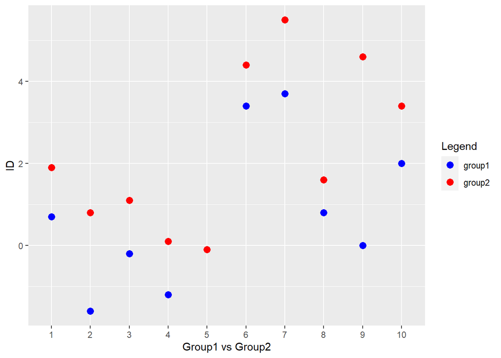

```r
colors <- c("group1" = "blue", "group2" = "red")

ggplot(data_wide, aes(x = ID)) +
    geom_point(aes(y = group1, color = "group1"), size=3) +
    geom_point(aes(y = group2, color = "group2"), size=3) +
    labs(x = "Group1 vs Group2",
         y = "ID",
         color = "Legend") +
    scale_color_manual(values = colors)
```

Score for each participant in group1 and group2

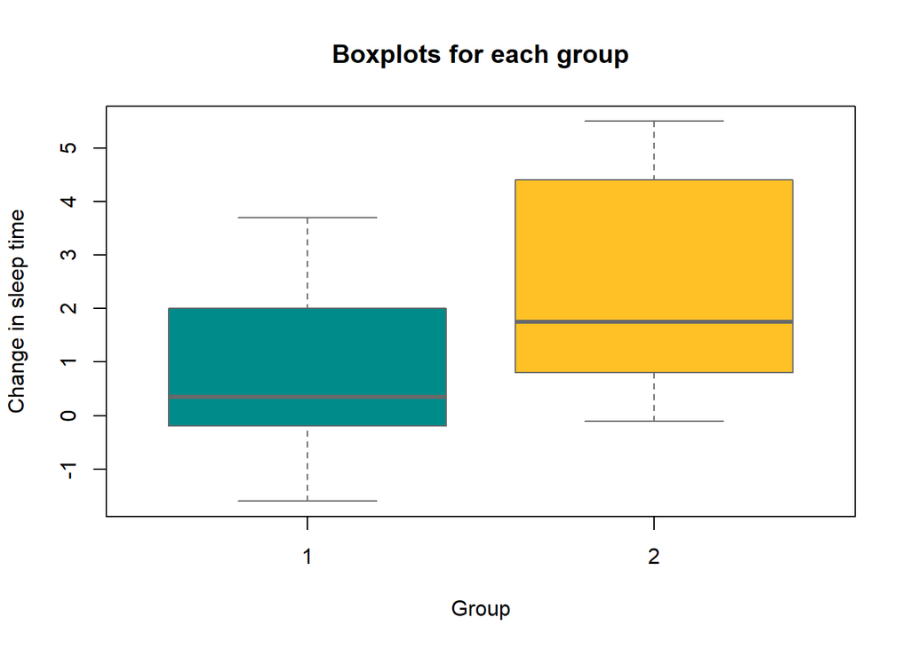

```r
boxplot(extra~group,
data=sleep,
main="Boxplots for each group",
xlab="Group",
ylab="Change in sleep time",
col=(c("darkcyan","goldenrod1")),
border="dimgrey"
)
```

Boxplots for each group

In order to choose a statistical test, I have to conduct normality test, because the sample is too small $(n=10)$

I use Q-Q plot to assess normal distribution

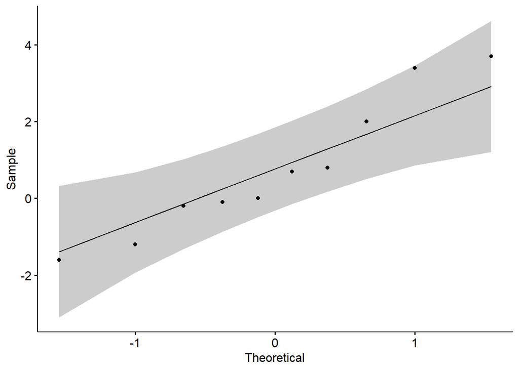

```r
ggqqplot(data_wide$group1)
```

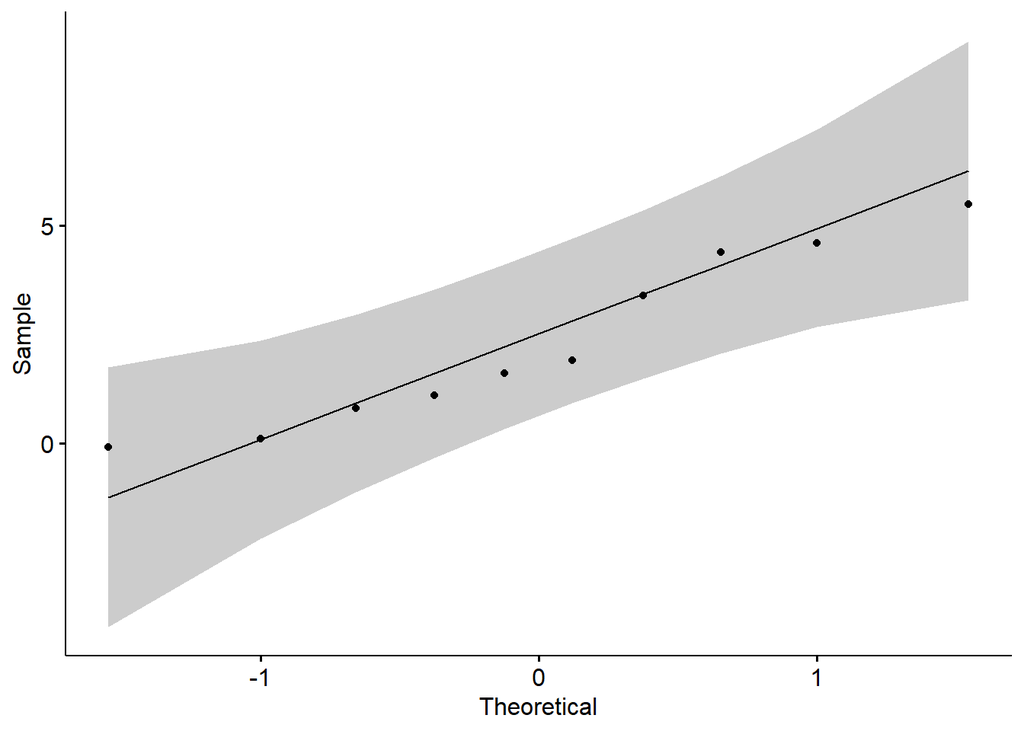

```r
ggqqplot(data_wide$group2)
```

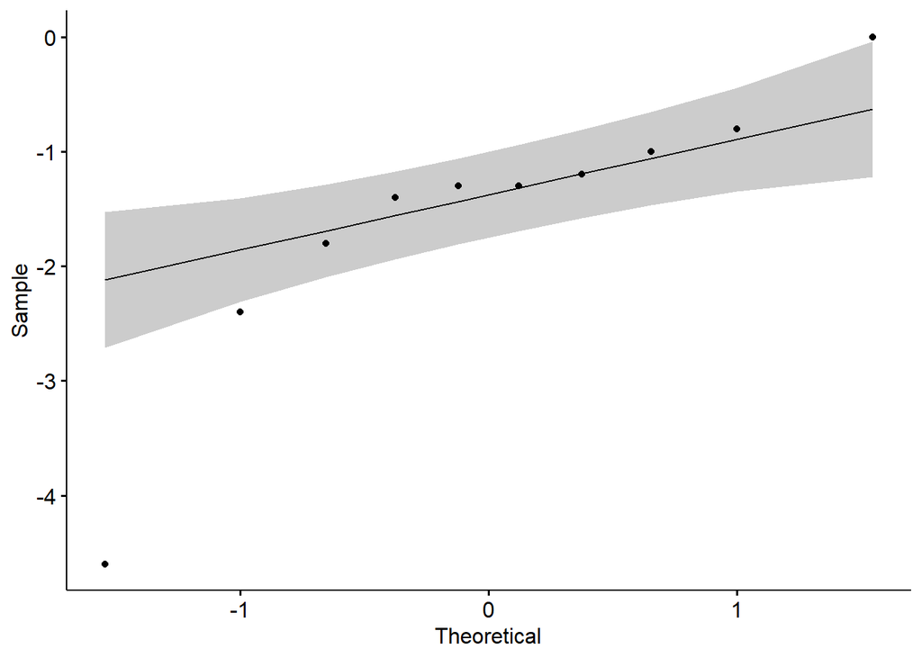

```r
ggqqplot(data_wide$difference)
```

All point fall more or less along the reference line with exception in one point, but the distribution is still ‘normal’ enough to perform a paired t-test

Here I define null hypothesis and alternative hypothesis, where $\bar{d} = \bar{x}_2 - \bar{x}_1$ is mean difference between second and first group.

$$H_0: \bar{d} \leq 0
\\H_1: \bar{d} > 0$$

Due to the fact that we do not know true mean and true variance, sample is small and data can be considered as normal distribution, I will use a paired t-test (degrees of freedom = 9)

```r
data1 <- data_wide$group1
data2 <- data_wide$group2

t <- t.test(data2, data1, paired = TRUE, alternative = "greater")
t
```

```
##
##  Paired t-test
##
## data:  data2 and data1
## t = 4.0621, df = 9, p-value = 0.001416
## alternative hypothesis: true difference in means is greater than 0
## 95 percent confidence interval:
##  0.8669947       Inf
## sample estimates:
## mean of the differences
##                    1.58
```

P-value is equal to $0.001416$ and is less than alpha $p-value < 0.05$, then we can reject $H_0$ Confidence interval equals $[0.8669947, \infty]$.

### B2

In this exercise you will work with `chickwts` dataset of measurements of chicken weights in $6$ independent groups fed with different types of food.

```r
data(chickwts)
head(chickwts)
```

```
##   weight      feed
## 1    179 horsebean
## 2    160 horsebean
## 3    136 horsebean
## 4    227 horsebean
## 5    217 horsebean
## 6    168 horsebean
```

Your task is to compare all groups with each other in pairs. Choose a proper test for such comparisons. Use significance level $\alpha = 0.05$.

How many test do you have to run?

This time you have to choose a proper test and justify your choice, but you do not have to report results. Instead, consider whether what you did is correct in terms of statistics. In particular, think about the type I error rate. Is it fixed for the set of all tests? Is the probability of observing one or more type I errors (rejecting $H_0$ when it is true) $\alpha = 0.05$ or does it change somehow due to the fact that you run multiple tests?

If you can, try to estimate what is the probability of observing at least one type I error assuming that null hypothesis is true in all cases. Assume that all tests are independent from each other (which makes sense if $H_0$ holds in every case).

SOLUTION

Here I start with plotting the data to see how the mean weight is distributes across feeds.

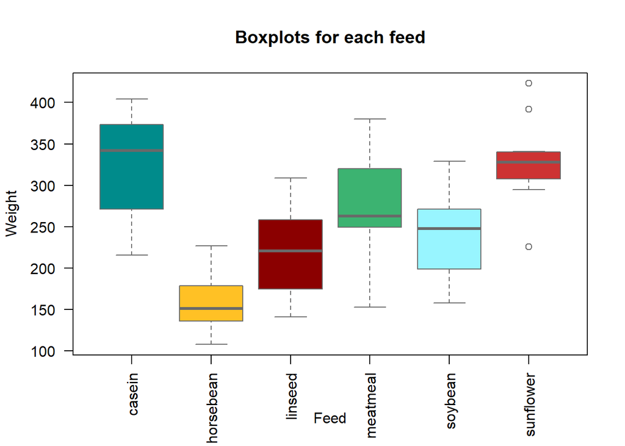

```r
boxplot(weight~feed,
data=chickwts,
las=2,
main="Boxplots for each feed",
xlab="Feed",
ylab="Weight",
col=(c("darkcyan","goldenrod1", "darkred", "mediumseagreen", "cadetblue1", "brown3")),
border="dimgrey"
)
```

To pick the right test I have to assess normality of distribution, because the sample is not big enough.

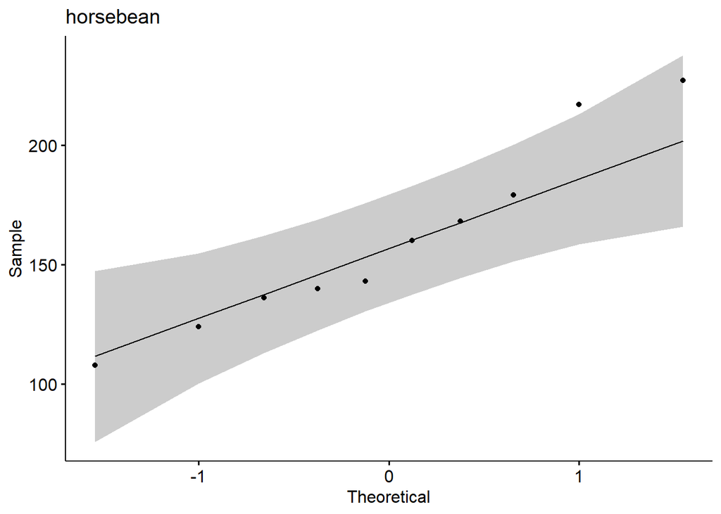

```r
ggqqplot(subset(chickwts, feed == "horsebean")$weight, title = "horsebean")
```

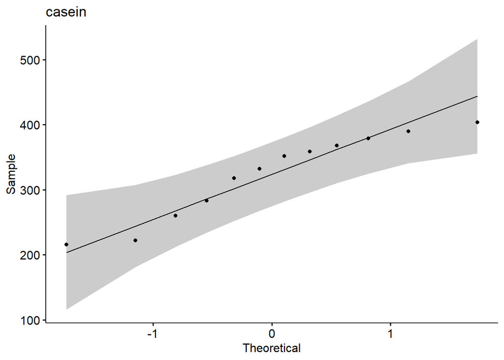

```r
ggqqplot(subset(chickwts, feed == "casein")$weight, title = "casein")
```

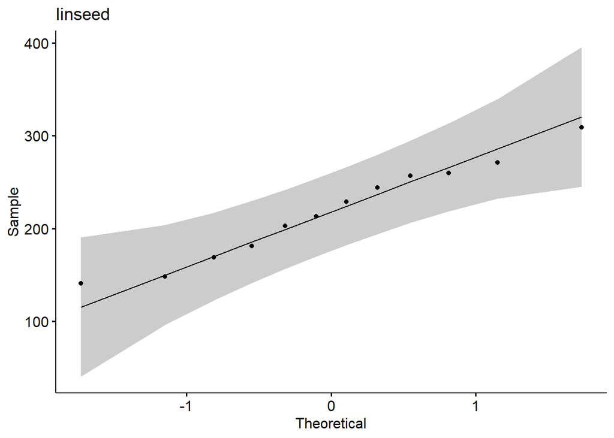

```r
ggqqplot(subset(chickwts, feed == "linseed")$weight, title = "linseed")
```

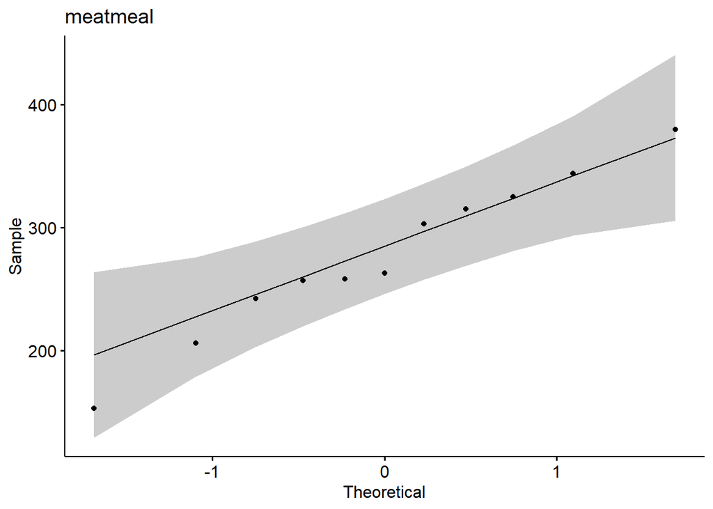

```r
ggqqplot(subset(chickwts, feed == "meatmeal")$weight, title = "meatmeal")
```

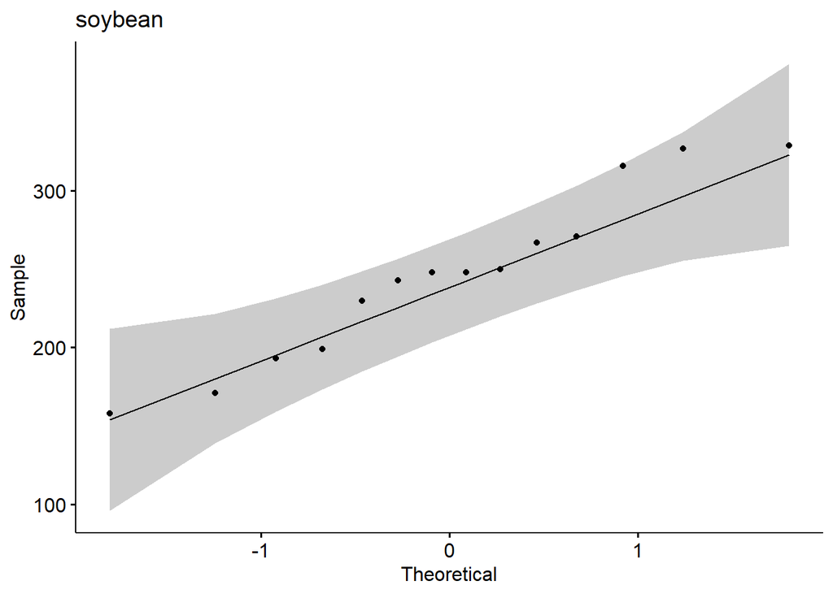

```r
ggqqplot(subset(chickwts, feed == "soybean")$weight, title = "soybean")
```

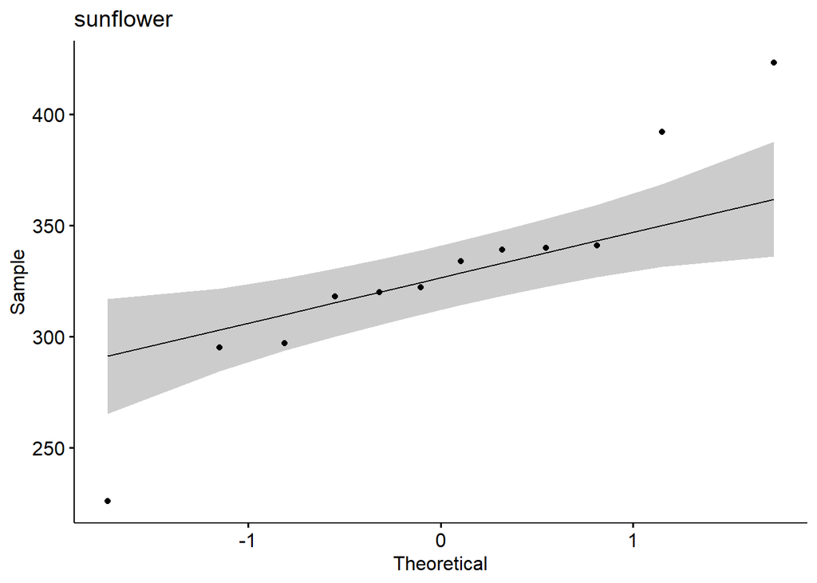

```r
ggqqplot(subset(chickwts, feed == "sunflower")$weight, title = "sunflower")
```

```r
shapiro.test(subset(chickwts, feed == "horsebean")$weight)
```

```
##
##  Shapiro-Wilk normality test
##
## data:  subset(chickwts, feed == "horsebean")$weight
## W = 0.93758, p-value = 0.5264
```

```r
shapiro.test(subset(chickwts, feed == "sunflower")$weight)
```

```
##
##  Shapiro-Wilk normality test
##
## data:  subset(chickwts, feed == "sunflower")$weight
## W = 0.92809, p-value = 0.3603
```

From the plots we can see that the data is distributed more or less normally. To be sure I performed Shapiro-Wilk normality test for sunflower and horsebean and both results indicate that the distribution is pretty much normal. With those results we can perform a pairwise t test.

My task is to compare means of 6 groups in pairs. Then my hypotheses for each comparison would be:

$$H_0: \mu_i - \mu_j = 0
\\H_1: \mu_i - \mu_j \neq 0$$

```r
choose(n=6,k=2)
```

```
## [1] 15
```

```r
pairwise.t.test(chickwts$weight, chickwts$feed, alternative="two.sided", p.adj="bonferroni")
```

```
##
##  Pairwise comparisons using t tests with pooled SD
##
## data:  chickwts$weight and chickwts$feed
##
##           casein  horsebean linseed meatmeal soybean
## horsebean 3.1e-08 -         -       -        -
## linseed   0.00022 0.22833   -       -        -
## meatmeal  0.68350 0.00011   0.20218 -        -
## soybean   0.00998 0.00487   1.00000 1.00000  -
## sunflower 1.00000 1.2e-08   9.3e-05 0.39653  0.00447
##
## P value adjustment method: bonferroni
```

I used Bonferonni correction, because the test number is not so big and we do not have to worry about big Type II error which is associated with using Bonferonni while having large test number.

### B3

In this exercise you will work with a dataset about hair and eye colors in a group of students. It has a form of a 3-dimensional array (two tables stacked one on top of another).

Aggregate the data so it is not split by sex and run a test to check whether hair and eye colors are independent. Would you trust results of the same test for individual sexes to the same extent as previously? Justify your answer.

**HINT.** Warnings thrown by `R` can be insightful here.

SOLUTION

```r
data(HairEyeColor)
data_agg <- apply(HairEyeColor, c(1, 2), sum)
data_agg
```

```
##        Eye
## Hair    Brown Blue Hazel Green
##   Black    68   20    15     5
##   Brown   119   84    54    29
##   Red      26   17    14    14
##   Blond     7   94    10    16
```

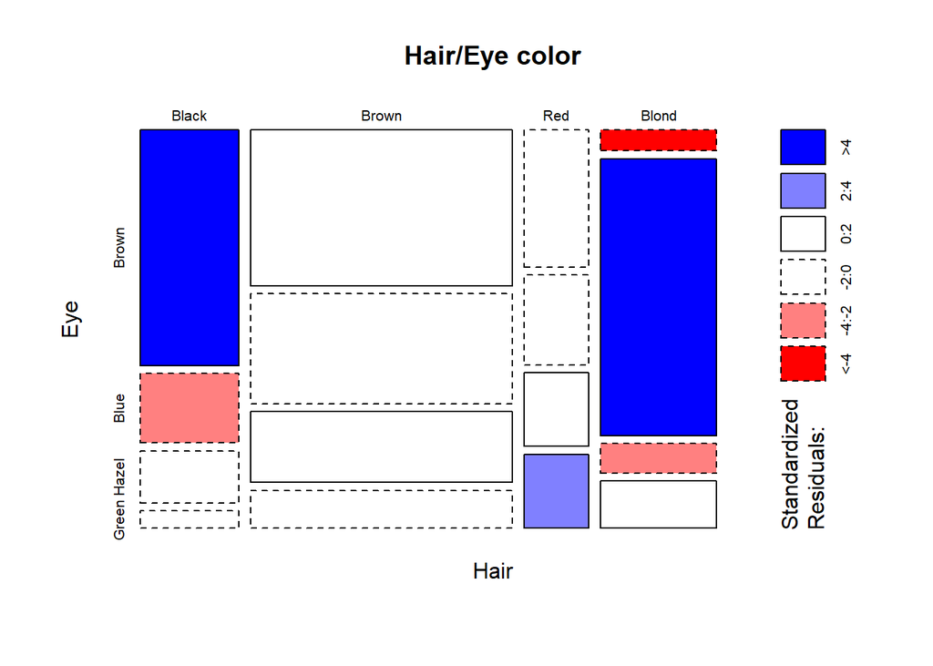

```r
mosaicplot(data_agg, main = "Hair/Eye color", shade = TRUE)
```

Assuming the data was random, blue color in the plot means that the observed value is higher than the expected value and red color indicates that the observed value is lower than the expected value.

$$H_0: \text {Hair and eye color are independent}
\\H_1: \text {Hair and eye color are dependent from each other}$$

Expected values:

```r
data_e <- data_agg
for (row in 1:length(data_agg[,1])) {
  for (column in 1:length (data_agg[1,])){
    data_e[row,column] <- round((sum(data_agg[row,])*sum(data_agg[,column]))/ sum(data_agg))
  }
}
data_e
```

```
##        Eye
## Hair    Brown Blue Hazel Green
##   Black    40   39    17    12
##   Brown   106  104    45    31
##   Red      26   26    11     8
##   Blond    47   46    20    14
```

In order to test independence I will perform a $\chi^2$ test, as it is the best for joint distributions of pairs of categorical variables and expected value of each cell is more than 5 (so it is big enough). $\alpha = 0.05$

```r
chisq.test(data_agg)
```

```
##
##  Pearson's Chi-squared test
##
## data:  data_agg
## X-squared = 138.29, df = 9, p-value < 2.2e-16
```

```r
chisq.test(x = data_agg, p = data_e / sum(data_e))
```

```
##
##  Pearson's Chi-squared test
##
## data:  data_agg
## X-squared = 138.29, df = 9, p-value < 2.2e-16
```

I calculated $\chi^2$ test with and without my calculated expected values just to be sure it is done right. We can see that they are the same. Obtained $p-value < 2.2e-16 < 0.05$ indicates that the $H_0$ can be rejected.

```r
female <- HairEyeColor[,,"Female"]
male <- HairEyeColor[,,"Male"]

data_f <- data_agg
for (row in 1:length(female[,1])) {
  for (column in 1:length (female[1,])){
    data_f[row,column] <- round((sum(female[row,])*sum(female[,column]))/ sum(female))
  }
}
data_f
```

```
##        Eye
## Hair    Brown Blue Hazel Green
##   Black    20   19     8     5
##   Brown    56   52    21    14
##   Red      14   13     5     4
##   Blond    32   30    12     8
```

```r
data_m <- data_agg
for (row in 1:length(male[,1])) {
  for (column in 1:length (male[1,])){
    data_f[row,column] <- round((sum(male[row,])*sum(male[,column]))/ sum(male))
  }
}
data_m
```

```
##        Eye
## Hair    Brown Blue Hazel Green
##   Black    68   20    15     5
##   Brown   119   84    54    29
##   Red      26   17    14    14
##   Blond     7   94    10    16
```

Below I try to perform the same test for each of the sexes separately. However, we cannot trust these results, because the sample sizes in some cases is too small. $\chi^2$ test should be applied when expected value of each cell is more than 5, and this is not the case.

```r
chisq.test(female)
```

```
##
##  Pearson's Chi-squared test
##
## data:  female
## X-squared = 106.66, df = 9, p-value < 2.2e-16
```

```r
chisq.test(male)
```

```
##
##  Pearson's Chi-squared test
##
## data:  male
## X-squared = 41.28, df = 9, p-value = 4.447e-06
```

Final report: A $\chi^2$ test was performed on categorical variables to test their independence with degrees of freedom $df = 9$. The results are: $\chi^2 = 138.29$, $p-value < 2.2e-16$. $p-value < 0.05$ indicates that $H_0$ can be rejected, meaning that hair and eye color in our data have significant association and therefore are not independent.

### B4

You will work with `iris` dataset of measurements of petal and sepal lenghts and widths for three different species of *iris* flowers.

```r
head(iris)
```

```
##   Sepal.Length Sepal.Width Petal.Length Petal.Width Species
## 1          5.1         3.5          1.4         0.2  setosa
## 2          4.9         3.0          1.4         0.2  setosa
## 3          4.7         3.2          1.3         0.2  setosa
## 4          4.6         3.1          1.5         0.2  setosa
## 5          5.0         3.6          1.4         0.2  setosa
## 6          5.4         3.9          1.7         0.4  setosa
```

Check whether sepals of *setosa* flowers are on average longer in than those of *virginica*. Choose a proper test and hypothesis. Use $\alpha = 0.01$.

Report results correctly and visualize them in manner that clearly presents your results.

**NOTE.** There are good ways to visualize results. Anything that is legible and presents the results will be accepted.

SOLUTION

```r
setosa <- subset(iris, Species == "setosa")
virginica <- subset(iris, Species == "virginica")
v_mean <- mean(virginica$Sepal.Length)
s_mean <- mean(setosa$Sepal.Length)
var_v <- var(virginica$Sepal.Length)
var_s <- var(setosa$Sepal.Length)
n_v <- length(virginica$Sepal.Length)
n_s <- length(setosa$Sepal.Length)
summary(iris)
```

```
##   Sepal.Length    Sepal.Width     Petal.Length    Petal.Width
##  Min.   :4.300   Min.   :2.000   Min.   :1.000   Min.   :0.100
##  1st Qu.:5.100   1st Qu.:2.800   1st Qu.:1.600   1st Qu.:0.300
##  Median :5.800   Median :3.000   Median :4.350   Median :1.300
##  Mean   :5.843   Mean   :3.057   Mean   :3.758   Mean   :1.199
##  3rd Qu.:6.400   3rd Qu.:3.300   3rd Qu.:5.100   3rd Qu.:1.800
##  Max.   :7.900   Max.   :4.400   Max.   :6.900   Max.   :2.500
##        Species
##  setosa    :50
##  versicolor:50
##  virginica :50
##
##
##
```

Hypotheses:

$$H_0: \mu_s \leq \mu_v
\\H_1: \mu_s > \mu_v
\\\alpha = 0.01$$

Here I visualize data to see how mean length of sepals varies for setosa and virginica.

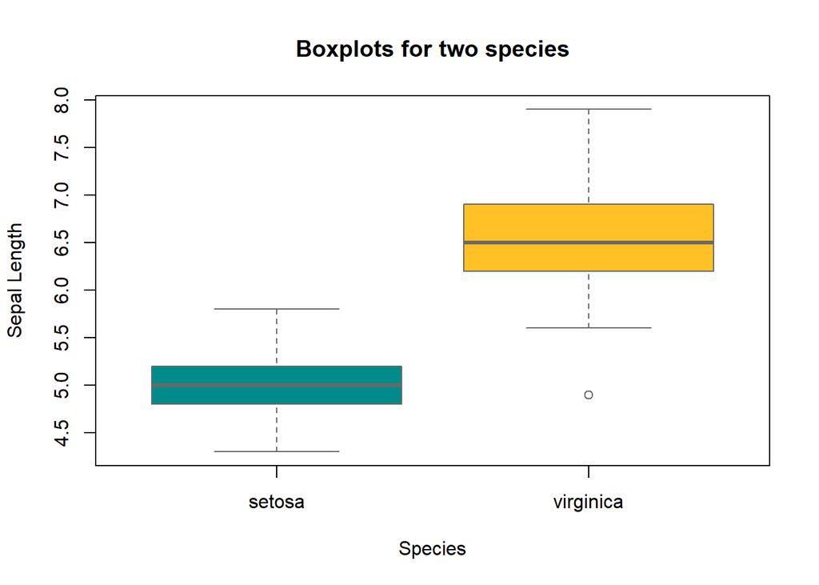

```r
boxplot(setosa$Sepal.Length, virginica$Sepal.Length,
main="Boxplots for two species",
names = c("setosa", "virginica"),
xlab="Species",
ylab="Sepal Length",
col=(c("darkcyan","goldenrod1")),
border="dimgrey"
)
```

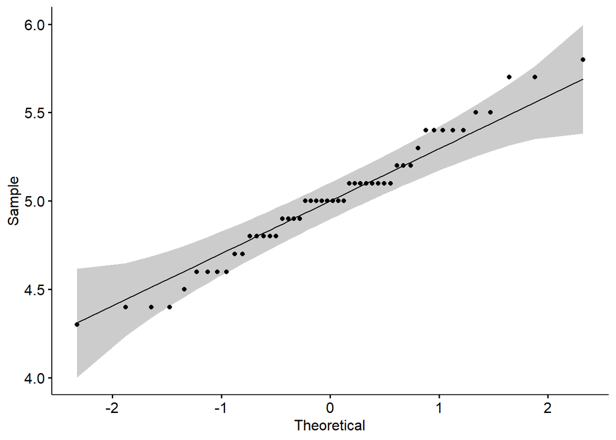

```r
ggqqplot(setosa$Sepal.Length)
```

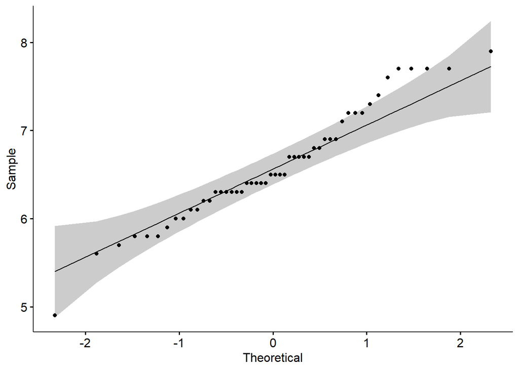

```r
ggqqplot(virginica$Sepal.Length)
```

Samples are big enough, so I can perform z-test. However, to be sure I plot data on QQ plots to assess normality of distribution. Here we can see that the data distribution is close enough to normal. $z=\frac{\bar{x_s} - \bar{x_v} - \Delta} {\sqrt{\frac {s_s^2} {n_s} + \frac {s_v^2} {n_v}}} \sim N (0,1)$

```r
dbar   <- s_mean - v_mean
s_dbar <- sqrt(var_s/n_s + var_v/n_v)
z      <- dbar / s_dbar
alpha <- 0.01
qnorm(1-alpha)
```

```
## [1] 2.326348
```

$z-score = -15.3862$

Constructing rejection region for $\alpha = 0.01$:

$q_z^{0.99} \approx 2.326$ then rejection region is $R=[2.326, \infty]$ z-score $(-15.3862)$ doesn’t fall into $[2.326, \infty]$ but to make proper judgments I will calculate p-value.

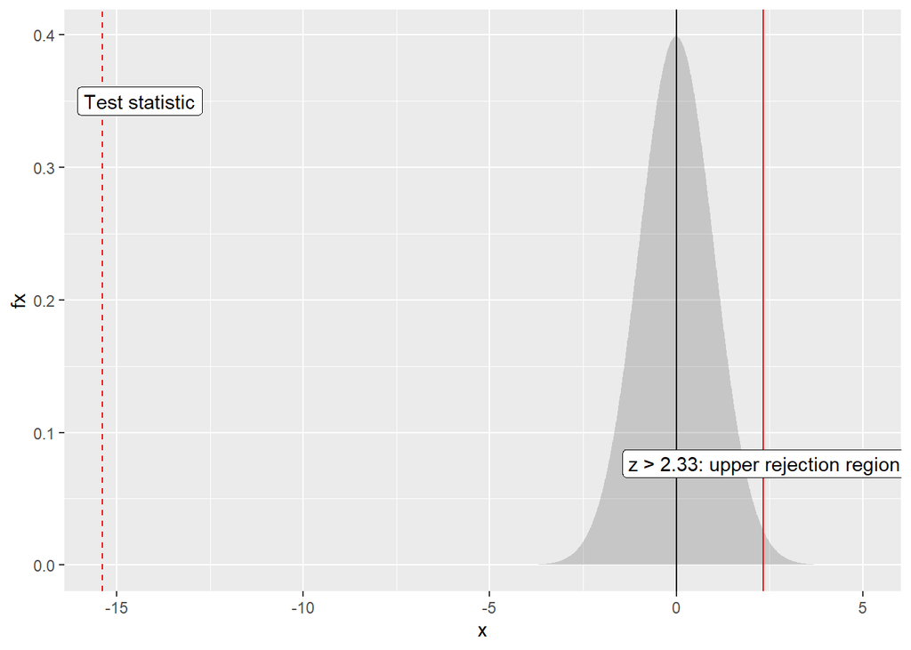

```r
alpha <- 0.01
q_upper <- qnorm(1-alpha)

data <- tibble(
  x = seq(-5,5, by=.01),
  fx = dnorm(x, mean = 0, sd = 1),
  is_rejection = abs(x) >= qnorm(1-alpha, mean = 0, sd = 1)
)

ggplot(data, aes(x=x, y=fx)) +
  geom_ribbon(aes(ymin = 0, ymax = fx), alpha = .2) +
  geom_vline(aes(xintercept = 0)) +
  geom_vline(aes(xintercept = q_upper), color = "red") +
  geom_vline(aes(xintercept = z),linetype=2, color = "red") +
  annotate("label", x = q_upper-3, y = dnorm(q_upper)+0.05, label = sprintf("z > %.2f: upper rejection region", q_upper), hjust = .10) +
  annotate("label", x = z+1, y = .35, label = "Test statistic")
```

Visualization of rejection region

```r
pvalue <- 1 - pnorm(z)
pvalue
```

```
## [1] 1
```

Here I choose a right way to calculate p-value with regard to null hypothesis and we can see it is 1

One-sided confidence interval is $CI^{one-sided}_{1-\alpha} = [-1.82, \infty]$

```r
dbar - q_upper*s_dbar
```

```
## [1] -1.821194
```

p-value is bigger than alpha, so we cannot reject $H_0$

Final report: The mean in the setosa sample was $5.006$ $(s^2 \approx 0.12, n = 50)$ and in the virginica sample $6.588$ $(s^2 \approx 0.4, n = 50)$. A one-sided z-test showed that the setosa mean is not statistically significantly bigger than virginica mean, $z-score = -15.3862$, $p-value \approx 1$. 99% one-sided confidence interval is $[-1.82, \infty]$

### B5

In this exercise you will work with `diamonds` dataset. It consists of many different measurements for a set $53 940$ diamonds of different types and quality. However, here you are interested in the correlation between `carat` and `price`.

```r
head(diamonds)
```

```
## # A tibble: 6 x 10
##   carat cut       color clarity depth table price     x     y     z
##   <dbl> <ord>     <ord> <ord>   <dbl> <dbl> <int> <dbl> <dbl> <dbl>
## 1  0.23 Ideal     E     SI2      61.5    55   326  3.95  3.98  2.43
## 2  0.21 Premium   E     SI1      59.8    61   326  3.89  3.84  2.31
## 3  0.23 Good      E     VS1      56.9    65   327  4.05  4.07  2.31
## 4  0.29 Premium   I     VS2      62.4    58   334  4.2   4.23  2.63
## 5  0.31 Good      J     SI2      63.3    58   335  4.34  4.35  2.75
## 6  0.24 Very Good J     VVS2     62.8    57   336  3.94  3.96  2.48
```

Consider *cuts* of diamonds which is a jargon term of general quality.

```r
table(diamonds$cut)
```

```
##
##      Fair      Good Very Good   Premium     Ideal
##      1610      4906     12082     13791     21551
```

First, create a new column in which you define a simplified classification based on cuts. Specifically, you should collapse `Fair`, `Good` and `Very Good` together and join `Premium` and `Ideal` so they make a second class. Use your new classification to test if the correlation between `carat` and `price` is the same in both groups.

Try to report your results in a reasonable way. They should be more or less understandable for a lay person, but also provide more finely-grained details. In particular, you should somehow show how much uncertainty there is around your best point estimate.

SOLUTION

```r
diamonds$cut2 <- ifelse(diamonds$cut == "Premium" | diamonds$cut == "Ideal", "Amazing", "Great")
amazing <- subset(diamonds, cut2 == "Amazing")
great <- subset(diamonds, cut2 == "Great")
n_a <- length(amazing$price)
n_g <- length(great$price)
table(diamonds$cut2)
```

```
##
## Amazing   Great
##   35342   18598
```

Here I join ‘Premium’ and ‘Ideal’ to one category: ‘Amazing’ and the rest (‘Fair’, ‘Good’ and ‘Very Good’) to ‘Great’

To pick a test for correlation I have to assess distribution of each group

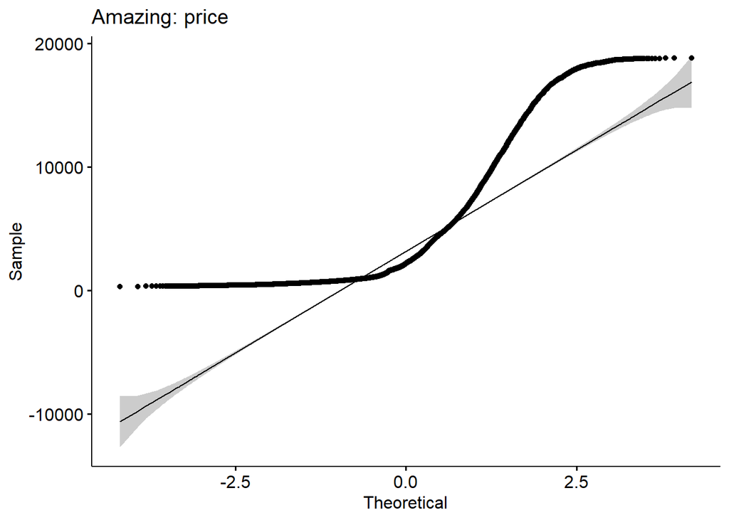

```r
ggqqplot(amazing$price, title = "Amazing: price")
```

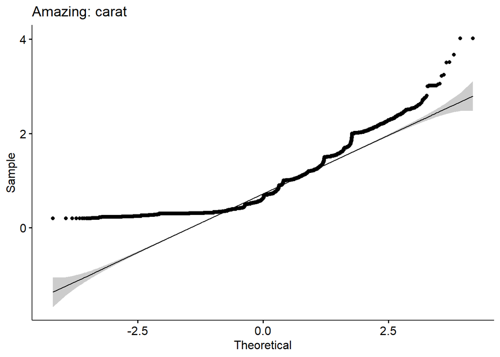

```r
ggqqplot(amazing$carat, title = "Amazing: carat")
```

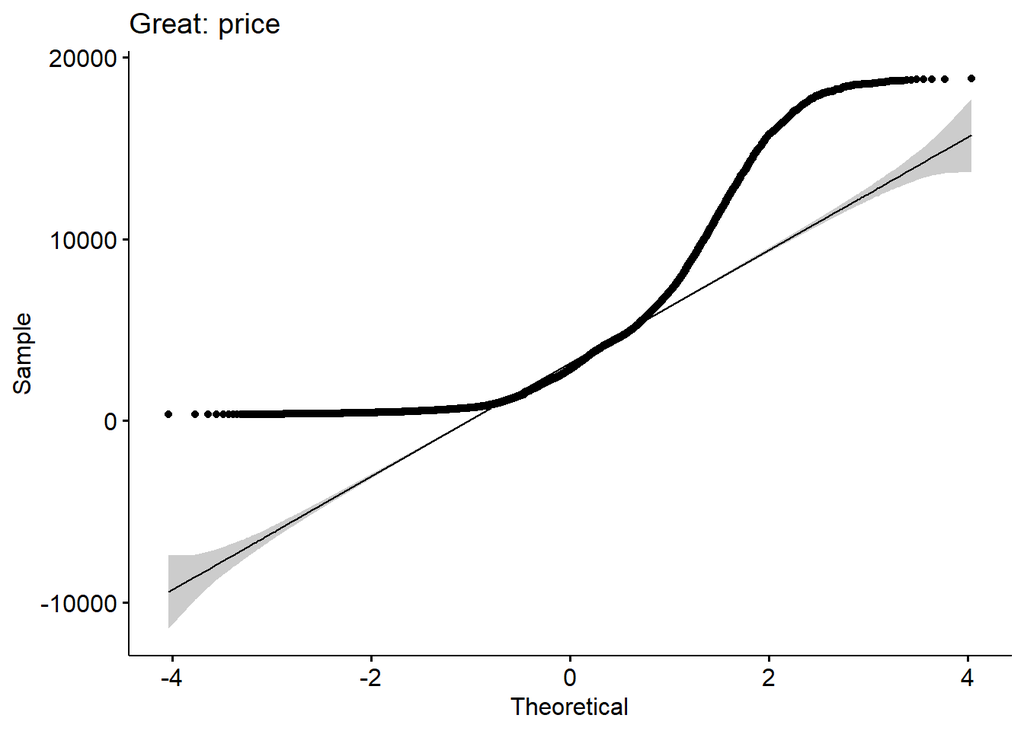

```r
ggqqplot(great$price, title = "Great: price")
```

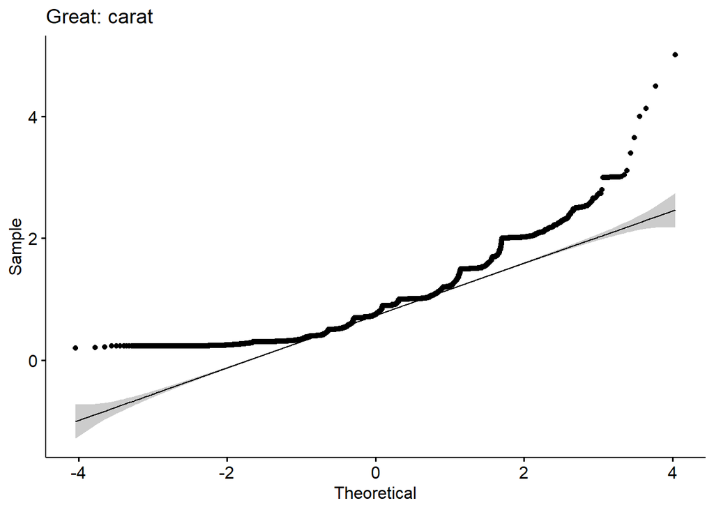

```r
ggqqplot(great$carat, title = "Great: carat")
```

The distribution is not normal, therefore, I will conduct a Spearman rank test

Hypotheses: $\rho_a$ means correlation coefficient in ‘amazing’ group, and $\rho_g$ in ‘great’ group

$$H_0: \rho_a = \rho_g
\\H_1: \rho_a \neq \rho_g$$

```r
rho_a <- cor(amazing$carat, amazing$price, method = "spearman")
rho_g <- cor(great$carat, great$price, method = "spearman")
```

We can see that $\rho_a \approx 0.959$ and $\rho_g \approx 0.962$ which are both extremely strong results.

Here I visualize raw data to present how it is distributed in terms of linear combination.

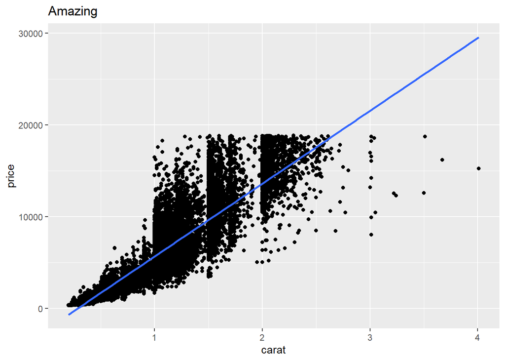

```r
ggplot(amazing, aes(x = carat, y = price)) +
geom_point() +
labs(title="Amazing")+
geom_smooth(method = "lm", formula = y ~ x, se = FALSE)
```

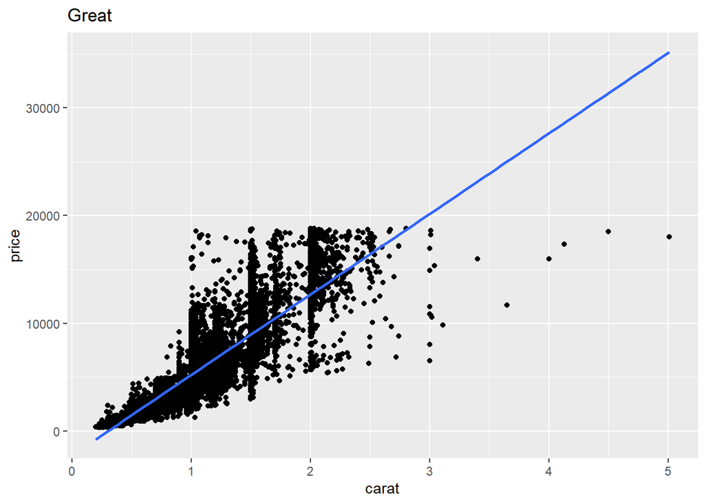

```r
ggplot(great, aes(x = carat, y = price)) +
geom_point() +
labs(title="Great")+
geom_smooth(method = "lm", formula = y ~ x, se = FALSE)
```

Here I visualize rank data which may give better view on how they are correlated.

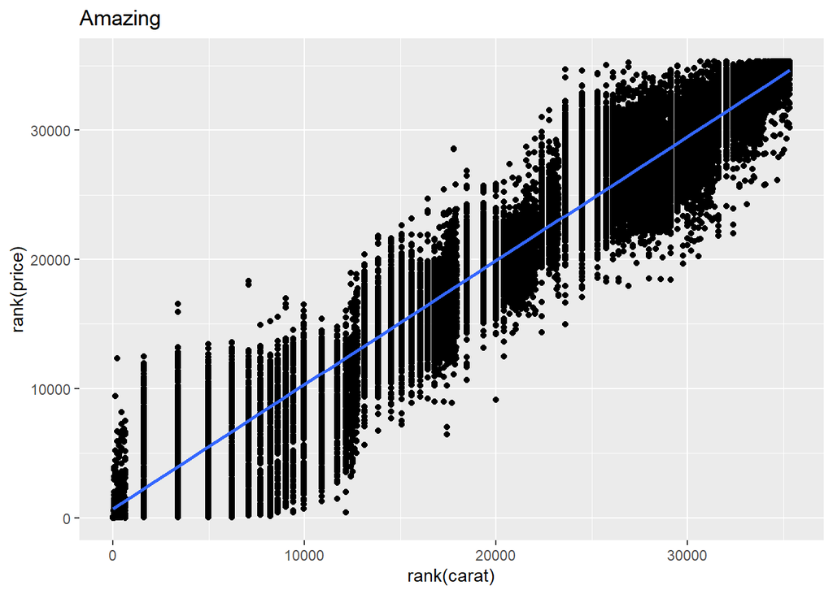

```r
ggplot(amazing, aes(x = rank(carat), y = rank(price))) +
geom_point() +
labs(title="Amazing")+
geom_smooth(method = "lm", formula = y ~ x, se = FALSE)
```

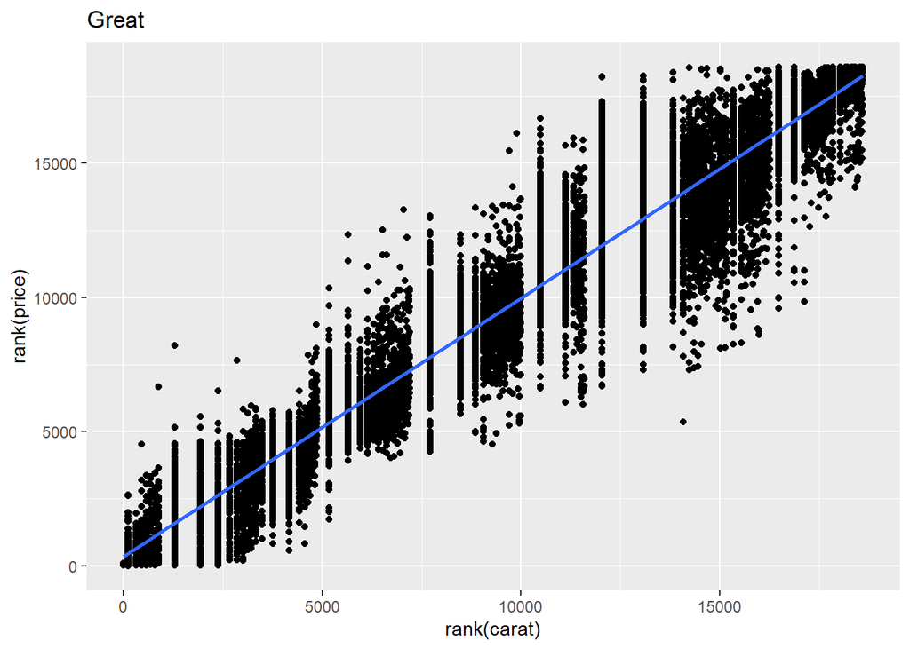

```r
ggplot(great, aes(x = rank(carat), y = rank(price))) +
geom_point() +
labs(title="Great")+
geom_smooth(method = "lm", formula = y ~ x, se = FALSE)
```

Next I will show an uncertainty estimate of our best point estimates $(\rho_a \approx 0.959$ and $\rho_g \approx 0.962)$ with bootstrap.

```r
set.seed(1910)
rho_boot_a <- boot(
    data = amazing,
    statistic = function(data, idx) {
        data <- data[idx,]
        cor(data$carat, data$price, method = "spearman")
    },
    R = 1000
)
rho_boot_a
```

```
##
## ORDINARY NONPARAMETRIC BOOTSTRAP
##
##
## Call:
## boot(data = amazing, statistic = function(data, idx) {
##     data <- data[idx, ]
##     cor(data$carat, data$price, method = "spearman")
## }, R = 1000)
##
##
## Bootstrap Statistics :
##      original        bias     std. error
## t1* 0.9594996 -1.007462e-05 0.0004753477
```

```r
set.seed(1910)
rho_boot_g <- boot(
    data = great,
    statistic = function(data, idx) {
        data <- data[idx,]
        cor(data$carat, data$price, method = "spearman")
    },
    R = 1000
)
rho_boot_g
```

```
##
## ORDINARY NONPARAMETRIC BOOTSTRAP
##
##
## Call:
## boot(data = great, statistic = function(data, idx) {
##     data <- data[idx, ]
##     cor(data$carat, data$price, method = "spearman")
## }, R = 1000)
##
##
## Bootstrap Statistics :
##      original        bias     std. error
## t1* 0.9624159 -2.416299e-05 0.0006869215
```

```r
quantile(rho_boot_a$t, probs = c(.025, 0.975))
```

```
##      2.5%     97.5%
## 0.9585334 0.9604204
```

```r
quantile(rho_boot_g$t, probs = c(.025, 0.975))
```

```
##      2.5%     97.5%
## 0.9611011 0.9637145
```

Confidence interval for correlation coefficients: $CI^{0.95}_a = [0.9585334, 0.9604204]$

$CI^{0.95}_g = [0.9611011, 0.9637145]$

Next step is transforming $\rho$ coefficients so that they become normally distributed and I can test $H_0$ using the statistical tests I already know, i.e. z-test. To do so I will perform Fisher Z-transformation $\rho'$. It is usually performed on r Pearson coeffitients, however, it also works for Spearman $\rho$.

```r
z_a <- 0.5*(log(1+rho_a) - log(1-rho_a))
z_a
```

```
## [1] 1.939567
```

```r
z_g <- 0.5*(log(1+rho_g) - log(1-rho_g))
z_g
```

```
## [1] 1.977675
```

The calculated z-scores are: $\rho_a \rightarrow z-score_a =1.939567$ $\rho_g \rightarrow z-score_g =1.977675$

‘Amazing’ and ‘great’ groups have both large samples, so Fisher transformation $\rho' \sim N(\rho', s_{\rho'})$ and $s_{\rho'} = \frac {1} {\sqrt{n-3}}$. Moreover, $\rho_a$ and $\rho_g$ are based on independent samples and $H_0 : \rho_a = \rho_g$. Then $z_{obs} \sim N(0,1)$, where $z_{obs}= \frac {z_a - z_g} {s}$ and $s = \sqrt{\frac {1}{n_a-3} + \frac {1}{n_g-3}}$

```r
se_diff <- sqrt(1/(n_a - 3) + 1/(n_g - 3))
z_obs <- (z_a - z_g) / se_diff
z_obs
```

```
## [1] -4.206466
```

Visualizing rejection region for $\alpha = 0.05$ and $z_{obs} = -4.206466$

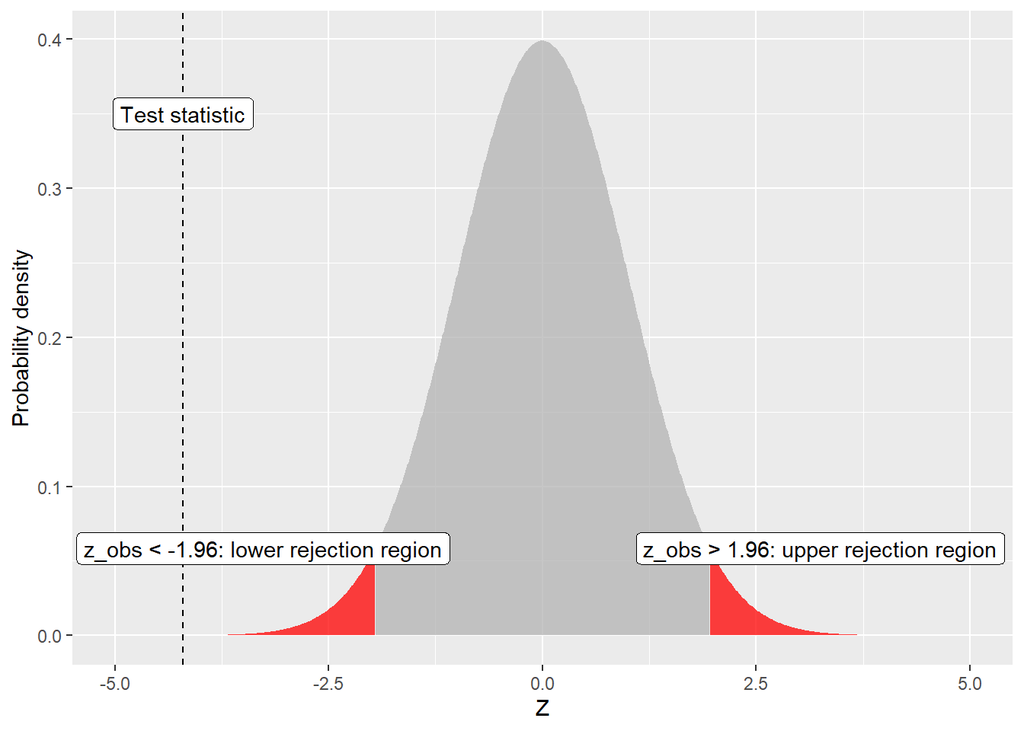

```r
alpha        <- 0.05
q_lower_tail <- qnorm(alpha/2)
q_upper_tail <- qnorm(1 - alpha/2)


tibble(
    Z         = seq(-5, 5, by = .01),
    density   = dnorm(Z),
    lower     = Z <= q_lower_tail,
    upper     = Z >= q_upper_tail,
    rejection = lower | upper
) %>%
    ggplot(aes(x = Z, y = density)) +
    geom_ribbon(data = . %>% filter(lower), aes(ymax = density, ymin = 0, fill = rejection), alpha = .75) +
    geom_ribbon(data = . %>% filter(upper), aes(ymax = density, ymin = 0, fill = rejection), alpha = .75) +
    geom_ribbon(data = . %>% filter(!rejection), aes(ymax = density, ymin = 0, fill = rejection), alpha = .75) +
    geom_vline(aes(xintercept = z_obs), linetype = 2) +
    annotate("label", x = z_obs, y = .35, label = "Test statistic") +
    annotate("label", x = q_lower_tail, y = dnorm(q_lower_tail), label = sprintf("z_obs < %.2f: lower rejection region", q_lower_tail), hjust = .8) +
    annotate("label", x = q_upper_tail, y = dnorm(q_upper_tail), label = sprintf("z_obs > %.2f: upper rejection region", q_upper_tail), hjust = .2) +
    guides(fill = FALSE) +
    scale_fill_manual(values = c("gray70", "red")) +
    labs(y = "Probability density")
```

Rejection region is $R = [-\infty, -1.96] \cup [1.96, \infty]$ and we can see that our $z-score = -4.206466$ belongs to that region. However, to be sure that we can reject $H_0$, I will calculate p-value.

```r
pnorm(-abs(z_obs)) + (1 - pnorm(abs(z_obs)))
```

```
## [1] 2.593949e-05
```

$p-value < 2.593949e-05 < alpha=0.05$, therefore $H_0$ can be rejected.

Next I will calculate confidence interval.

```r
(z_a-z_g) + c(q_lower_tail, q_upper_tail) * se_diff
```

```
## [1] -0.05586501 -0.02035227
```

Confidence interval equals to: $CI_{\alpha}=[-0.05586501 -0.02035227]$ and it does not contain $0$ ($H_0$), which means that we can reject $H_0$, which is consistent with previous findings.

Final report: The Spearman correlation coefficient $\rho$ in the first sample was $0.959$ $(n = 35342)$ and in the second sample $0.962$ $(n = 18598)$. With Fisher $\rho$ to z transformation $z-score=1.94$ for the first sample and $z-score=1.98$ for the second sample was calculated. A two-sided z-test showed that the difference is statistically significant, as $H_0$ can be rejected. $z-score_{obs} = -4.206$, $p-value < 2.593949e-05$. $95$% two-sided confidence interval is $CI_{0.95}=[-0.05586501 -0.02035227]$